# Practica FMF

Ana Marta Oliveira y Siria Catherine Íñiguez

## 1. Introducción

En el mundo de las finanzas, entender cómo cambian los tipos de interés es fundamental. A diferencia de las acciones de una empresa, que pueden subir o bajar por muchas razones, los tipos de interés dependen de la economía de un país y de las decisiones de sus gobernantes.

El objetivo de este trabajo es analizar la evolución histórica de la serie TB3MS (3-Month Treasury Bill Secondary Market Rate) para identificar sus propiedades estadísticas fundamentales y determinar qué Ecuación Diferencial Estocástica (SDE) es capaz de capturar su comportamiento dinámico de manera más fiel.

### 1.1. Contexto Económico de la Serie TB3MS

La serie `TB3MS` registra el rendimiento de las Letras del Tesoro de EE. UU. a tres meses. Debido a que cuenta con el respaldo total del gobierno estadounidense, se considera un activo “libre de riesgo” y funciona como la base de referencia para el sistema financiero global. Su análisis es fundamental por tres motivos principales:

- **Política Monetaria:** Esta tasa es el reflejo más directo de las decisiones de la Reserva Federal (la Fed). Cuando el banco central decide encarecer o abaratar el precio del dinero para controlar la economía, la serie TB3MS es la primera en reaccionar, marcando el rumbo de lo que costará el crédito a corto plazo.
- **Expectativas Inflacionarias:** El valor de esta tasa incorpora lo que el mercado espera que ocurra con los precios en el futuro cercano. Si los inversores prevén que la inflación va a subir, exigirán un mayor rendimiento en estas letras, convirtiendo a esta serie en un termómetro de las previsiones económicas del mercado.
- **Ciclos Económicos:** La serie funciona como un indicador adelantado de la actividad económica. En épocas de expansión, las tasas tienden a subir ante una mayor demanda de crédito y expectativas de crecimiento. Por el contrario, caídas bruscas en el TB3MS suelen preceder a periodos de recesión, ya que el mercado busca refugio en la seguridad de la deuda pública y anticipa que la Reserva Federal bajará los tipos para estimular la economía.

## 2. Visualización y Análisis Exploratorio

Para determinar qué tipo de proceso estocástico se ajusta mejor a estos datos, comenzaremos importando y graficando la serie. El objetivo es identificar visualmente propiedades como la reversión hacia la media, la presencia de valores negativos (o su ausencia) y la estructura de la volatilidad.

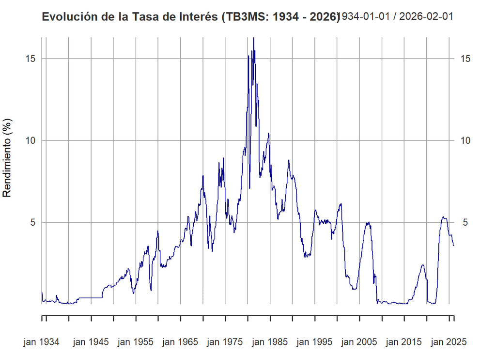

```r
library(yuima)
library(quantmod)

# Descarga y preparación de datos
TB3MS <- getSymbols("TB3MS", src = "FRED", auto.assign = FALSE)
serie_limpia <- na.omit(TB3MS)

# Visualización inicial (Análisis exploratorio)
plot(TB3MS,
     main = "Evolución de la Tasa de Interés (TB3MS: 1934 - 2026)",
     ylab = "Rendimiento (%)",
     xlab = "Año",
     col = "darkblue",
     lwd = 1.2)
grid()
```

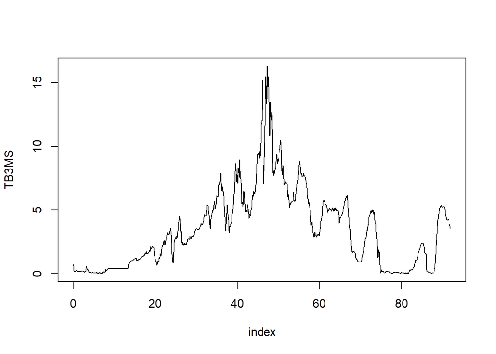

```r
# Creamos el objeto de datos
datos_y <- setData(serie_limpia, delta = 1/12)

# Comprobamos que el objeto está bien creado
modelo_base <- setYuima(data = datos_y)
plot(modelo_base)
```

Tras observar el gráfico de la serie histórica de la tasa **TB3MS (1934-2026)**, podemos concluir que el modelo de Movimiento Browniano Geométrico (GBM), definido por la Ecuación Diferencial Estocástica $dS_t = \mu S_t dt + \sigma S_t dW_t$, resulta inadecuado para representar este activo por las siguientes razones:

### El fenómeno del Límite Cero

Matemáticamente, un proceso GBM es estrictamente positivo y su naturaleza estocástica le impide permanecer estático en un valor determinado. No obstante, la evolución de la tasa TB3MS muestra una realidad distinta: tras la crisis financiera de 2008 y durante la pandemia de 2020, la tasa colapsó hasta situarse prácticamente en el **0%** y permaneció “anclada” en ese nivel durante años. Esta capacidad de la serie para presentar periodos de inactividad y estabilidad absoluta en su límite inferior contradice la formulación del GBM, el cual obligaría a la tasa a mantener fluctuaciones aleatorias constantes y proporcionales, haciendo imposible modelar un escenario de tipos estancados en el suelo.

### Estructura de la Volatilidad

Una de las restricciones más rígidas del GBM es que su volatilidad es directamente proporcional al nivel del proceso ($\sigma S_t$). Esto requeriría que, a niveles de tasas bajos, los movimientos fuesen imperceptibles, mientras que a niveles altos, los saltos fuesen máximos. Al contrastar la estabilidad observada en los años 40 con la agresiva subida de tipos iniciada en 2022 —partiendo ambos de niveles cercanos a cero—, queda demostrado que la variabilidad de la serie no depende del valor nominal de la tasa. Esta desconexión entre el nivel de la tasa y la magnitud de sus cambios confirma que la estructura de volatilidad del GBM es incompatible con los datos observados.

## 3. Definición de los modelos

### SDE Sugeridas para este modelo

Dado que estamos ante una tasa de interés a corto plazo con reversión a la media y un límite inferior claro, proponemos las siguientes SDE:

### 1. Modelo de Cox-Ingersoll-Ross (CIR)

Sería la opción recomendada porque soluciona el problema del “límite cero”. Su SDE es:
$$dX_t = (\theta_1 -
\theta_2 X_t) dt + \theta_3 \sqrt{X_t} dB_t$$
Su término $\sqrt{X_t}$ en la difusión hace que, a medida que la tasa se acerca a cero, la volatilidad disminuya, evitando que la serie se vuelva “loca” en niveles bajos. Además, es un proceso no negativo.

### 2. Modelo de Vasicek (Ornstein-Uhlenbeck)

También presenta reversión a la media, pero su volatilidad es constante:
$$dX_t = (\theta_1 - \theta_2 X_t)
dt + \theta_3 dB_t$$
Sin embargo, no considera que la volatilidad cambie con el nivel de la tasa y podría, teóricamente, generar tasas negativas, algo que no se aprecia en nuestra serie. De igual forma, vamos a probarlo para verificar que efectivamente no sería un proceso adecuado.

```r
# 2. Definición de los modelos
# 2.1 Modelo Vasieck (Ornstein-Uhlenbeck):
mod_vasicek <- setModel(drift = "theta1 - theta2*x", diffusion = "theta3",
                        state.variable = "x", solve.variable = "x")
# 2.2 Modelo CIR
mod_cir <- setModel(drift = "theta1 - theta2*x", diffusion = "theta3*sqrt(x)",
                    state.variable = "x", solve.variable = "x")

# Unión del modelo con los datos
yuima_v <- setYuima(data = datos_y, model = mod_vasicek)
yuima_c <- setYuima(data = datos_y, model = mod_cir)

# Parámetros para la estimación
param_init <- list(theta1 = 0.5, theta2 = 0.1, theta3 = 0.1)
low_par <- list(theta1 = 1e-5, theta2 = 1e-5, theta3 = 1e-5)
up_par <- list(theta1 = 20, theta2 = 10, theta3 = 10)

# Estimación QMLE
fit_vasicek <- qmle(yuima_v, start = param_init, lower = low_par, upper = up_par)
fit_cir <- qmle(yuima_c, start = param_init, lower = low_par, upper = up_par)

# Resultados
summary(fit_vasicek)
```

```
## Quasi-Maximum likelihood estimation
##
## Call:
## qmle(yuima = yuima_v, start = param_init, lower = low_par, upper = up_par)
##
## Coefficients:
##          Estimate Std. Error
## theta3 1.22569709 0.02614360
## theta1 0.31373312 0.19036675
## theta2 0.08263922 0.04129792
##
## -2 log L: 835.7449
```

```r
summary(fit_cir)
```

```
## Quasi-Maximum likelihood estimation
##
## Call:
## qmle(yuima = yuima_c, start = param_init, lower = low_par, upper = up_par)
##
## Coefficients:
##          Estimate Std. Error
## theta3 0.53653765 0.01148300
## theta1 0.08841239 0.02931494
## theta2 0.01671654 0.03143575
##
## -2 log L: -530.2561
```

```r
# Comparación de calidad del modelo con el critério AIC
cat("\n\nAIC Vasicek:", AIC(fit_vasicek), "\n")
```

```
##
##
## AIC Vasicek: 841.7449
```

```r
cat("AIC CIR:", AIC(fit_cir), "\n")
```

```
## AIC CIR: -524.2561
```

Para validar cuantitativamente las deficiencias teóricas expuestas, procedemos a la estimación formal del modelo de Movimiento Browniano Geométrico. Este paso nos permitirá contrastar, mediante el criterio AIC, si la estructura de este proceso es capaz de competir con los modelos de reversión a la media en el ajuste de los datos reales.

```r
# 2.3 Modelo GBM
gbm <- setModel(drift = "theta1*x", diffusion = "theta2*x")

# Unión del modelo GBM con los datos
yuima_g <- setYuima(data = datos_y, model = gbm)

# Parámetros para la estimación del GBM: theta1 y theta2
init_gbm <- list(theta1 = 0.5, theta2 = 0.1)
low_gbm <- list(theta1 = 1e-5, theta2 = 1e-5)
up_gbm <- list(theta1 = 20, theta2 = 10)

# Estimación QMLE para GBM
fit_gbm <- qmle(yuima_g, start = init_gbm, lower = low_gbm, upper = up_gbm)

# Resultados GBM
summary(fit_gbm)
```

```
## Quasi-Maximum likelihood estimation
##
## Call:
## qmle(yuima = yuima_g, start = init_gbm, lower = low_gbm, upper = up_gbm)
##
## Coefficients:
##        Estimate Std. Error
## theta2 1.030101 0.02205319
## theta1 0.330779 0.10734682
##
## -2 log L: 1375.966
```

```r
# Comparación Final de los 3 modelos
cat("AIC Vasicek: ", AIC(fit_vasicek), "\n")
```

```
## AIC Vasicek:  841.7449
```

```r
cat("AIC CIR:     ", AIC(fit_cir), "\n")
```

```
## AIC CIR:      -524.2561
```

```r
cat("AIC GBM:     ", AIC(fit_gbm), "\n")
```

```
## AIC GBM:      1379.966
```

Como se anticipaba, el Movimiento Browniano Geométrico presenta el AIC más elevado de los tres modelos comparados.Este resultado muestra que un proceso carente de reversión a la media y con una volatilidad estrictamente proporcional al nivel es incapaz de capturar la complejidad de la serie TB3MS, quedando descartado frente a las alternativas de Vasicek y CIR.

## 4. Elección del modelo: CIR vs. Vasicek

Para determinar cuál de las dos SDE captura mejor la dinámica de la serie TB3MS, se utilizó el criterio AIC. Con los resultados obtenidos en la salida anterior, se observa una diferencia entre ambos modelos extremadamente significativa. Mientras que el modelo de Vasicek presenta un AIC de 841.74, el modelo CIR alcanza un valor de -524.25. Confirmando la intuición inicial: la estructura de volatilidad del CIR se ajusta mejor a los tipos de interés que la volatilidad constante del modelo Vasicek.

```r
# Definimos 3 listas de parámetros iniciales diferentes
param_init1 <- list(theta1 = 0.5, theta2 = 0.1, theta3 = 0.1)
param_init2 <- list(theta1 = 2, theta2 = 0.5, theta3 = 0.5)
param_init3 <- list(theta1 = 0.1, theta2 = 0.05, theta3 = 0.2)

# Ejecutamos las estimaciones para el mejor modelo - CIR
fit1 <- qmle(yuima_c, start = param_init1, lower = low_par, upper = up_par)
fit2 <- qmle(yuima_c, start = param_init2, lower = low_par, upper = up_par)
fit3 <- qmle(yuima_c, start = param_init3, lower = low_par, upper = up_par)

# Comparamos resultados y errores estándar
summary(fit1)
```

```
## Quasi-Maximum likelihood estimation
##
## Call:
## qmle(yuima = yuima_c, start = param_init1, lower = low_par, upper = up_par)
##
## Coefficients:
##          Estimate Std. Error
## theta3 0.53653765 0.01148300
## theta1 0.08841239 0.02931494
## theta2 0.01671654 0.03143575
##
## -2 log L: -530.2561
```

```r
summary(fit2)
```

```
## Quasi-Maximum likelihood estimation
##
## Call:
## qmle(yuima = yuima_c, start = param_init2, lower = low_par, upper = up_par)
##
## Coefficients:
##          Estimate Std. Error
## theta3 0.53653765 0.01148300
## theta1 0.08841239 0.02931494
## theta2 0.01671654 0.03143575
##
## -2 log L: -530.2561
```

```r
summary(fit3)
```

```
## Quasi-Maximum likelihood estimation
##
## Call:
## qmle(yuima = yuima_c, start = param_init3, lower = low_par, upper = up_par)
##
## Coefficients:
##          Estimate Std. Error
## theta3 0.53653765 0.01148300
## theta1 0.08841239 0.02931494
## theta2 0.01671654 0.03143575
##
## -2 log L: -530.2561
```

### Análisis de estabilidad del estimador QMLE

Para validar la robustez de los parámetros obtenidos mediante el QMLE, se realizaron tres pruebas variando los valores iniciales.

A pesar de utilizar puntos de partida muy distintos, las estimaciones finales para $\theta_1$, $\theta_2$ y $\theta_3$ fueron idénticas en los tres casos.

Los errores estándar se mantuvieron constantes y reducidos, lo que indica que la aproximación del logaritmo de la verosimilitud según el esquema de Euler-Maruyama es estable para esta serie temporal. Esto demuestra que el algoritmo ha alcanzado un máximo global y no depende de la semilla inicial, garantizando así la fiabilidad de los resultados.

## 5. Contraste de hipótesis: validación del modelo

- $H_0$: El proceso observado sigue el modelo CIR con los parámetros estimados $\theta_0$.
- $H_1$: El proceso no se ajusta a dichos parámetros.

```r
# Contraste de hipótesis: validación del modelo
# Definición de la función de divergencia
phi1 <- function(x) { x * log(x) - x + 1 }
hoo <- as.list(coef(fit1))
# 1. Calculamos cuántos años reales tiene la serie
n_obs <- length(serie_limpia)
anos_totales <- n_obs / 12  # Asumiendo datos mensuales

# 2. Ajustamos el muestreo a la realidad histórica
samp <- setSampling(Initial = 0, Terminal = anos_totales, n = n_obs)
yuima_val <- setYuima(model = mod_cir, sampling = samp)

# 3. Usamos el primer valor real de la serie como punto de partida
x_inicio <- as.numeric(serie_limpia[1])

set.seed(123)
sim_validacion <- simulate(yuima_val, xinit = x_inicio, true.parameter = hoo)

# 4. Volvemos a lanzar el test
test_resultado <- phi.test(sim_validacion,
                           H0 = hoo,
                           phi = phi1,
                           start = hoo,
                           lower = low_par,
                           upper = up_par)
```

```
##
## estimating parameters via QMLE...
```

```r
print(test_resultado)
```

```
## Phi-Divergence test statistic based on phi = 'phi1'
## H0: theta3 = 0.537 theta1 = 0.0884 theta2 = 0.0167
## versus
## H1: theta3 = 0.5356 theta1 = 0.2581 theta2 = 0.0784
## H1 parameters estimated using QMLE
##
## Test statistic = 3.579, df = 3, p-value = 0.3106339
## ---
## Signif. codes:  0 '***' 0.001 '**' 0.01 '*' 0.05 '.' 0.1 ' ' 1
```

El resultado del contraste puede ser sensible a la especificación del horizonte temporal y la discretización utilizada en la simulación. Por este motivo, se ha ajustado el intervalo de muestreo para que coincida con la duración real de la serie histórica y el número de observaciones disponibles.

## 6. Simulación

```r
# Mejor modelo: CIR
mejor_fit <- fit_cir
mejor_modelo <- mod_cir

# Extraer parámetros estimados
params_estimados <- coef(mejor_fit)
print("Parámetros obtenidos por QMLE:")
```

```
## [1] "Parámetros obtenidos por QMLE:"
```

```r
print(params_estimados)
```

```
##     theta3     theta1     theta2
## 0.53653765 0.08841239 0.01671654
```

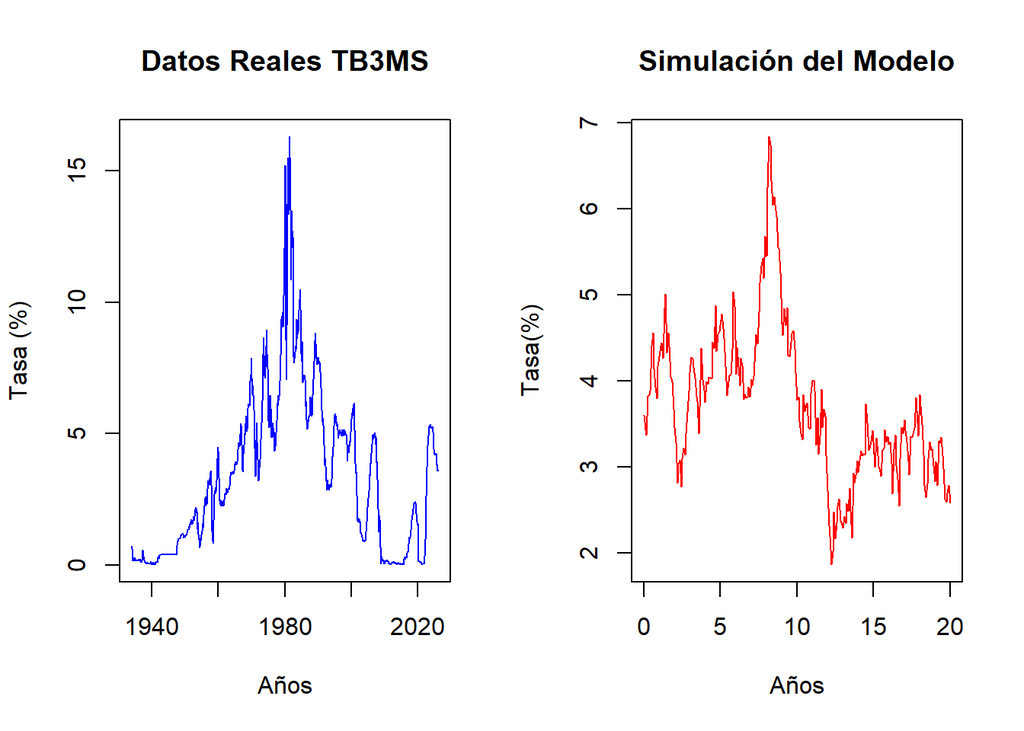

```r
# Simulación con los parámetros estimados
# Vamos a simular 20 años (240 meses) empezando desde el último valor real
ultimo_valor <- as.numeric(tail(serie_limpia, 1))
muestreo_sim <- setSampling(Initial = 0, Terminal = 20, n = 240)

set.seed(123) # Para que sea reproducible
simulacion_optima <- simulate(mejor_modelo,
                              xinit = ultimo_valor,
                              true.parameter = as.list(params_estimados),
                              sampling = muestreo_sim)

# Grafica: Datos Reales vs Simulación
par(mfrow=c(1,2), mar=c(5,4,4,2)+0.1)
plot.zoo(TB3MS, main="Datos Reales TB3MS", col="blue", xlab="Años", ylab="Tasa (%)")
plot(simulacion_optima, main="Simulación del Modelo", col="red", xlab="Años", ylab="Tasa(%)")
```

Aunque la simulación representa una proyección de 20 años partiendo del valor actual, la comparación visual permite verificar que el modelo preserva las características intrínsecas de la serie original: reversión a la media y volatilidad dependiente del nivel. La simulación no busca predecir el valor exacto, sino demostrar que el “ruido” y las “tendencias” generadas son estadísticamente consistentes con el comportamiento histórico de la serie TB3MS.

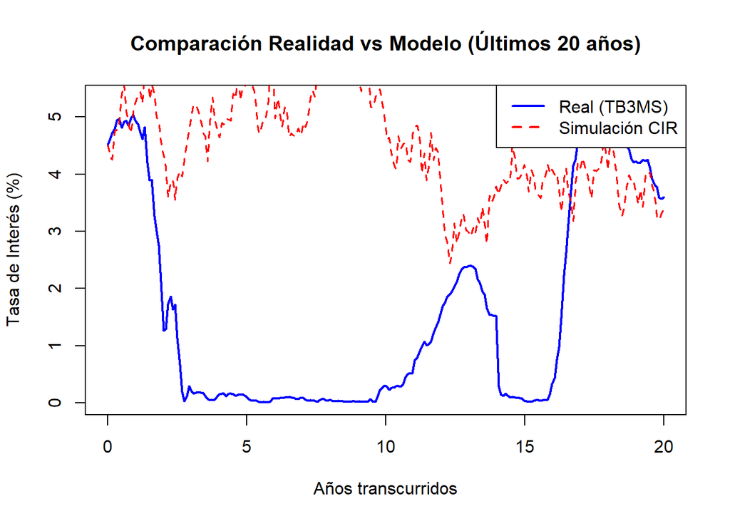

```r
# Esto es prueba de utilizar modelo para los últimos 20 años = 240 meses
n_meses <- 240
datos_20 <- tail(serie_limpia, n_meses)
valor_inicial_20 <- as.numeric(datos_20[1])

# Configurar el muestreo para 20 años
muestreo_hist <- setSampling(Initial = 0, Terminal = 20, n = n_meses-1)

# Simular partiendo del valor histórico
set.seed(123)
sim_historica <- simulate(mejor_modelo,
                          xinit = valor_inicial_20,
                          true.parameter = as.list(params_estimados),
                          sampling = muestreo_hist)

# Grafico real vs simulación
y_sim <- as.numeric(sim_historica@data@zoo.data[[1]])
t_sim <- seq(0, 20, length.out = n_meses)


plot(t_sim, as.numeric(datos_20), type="l", col="blue", lwd=2,
     main="Comparación Realidad vs Modelo (Últimos 20 años)",
     ylab="Tasa de Interés (%)", xlab="Años transcurridos")
lines(t_sim, y_sim, col="red", lwd=1.5, lty=2)
legend("topright", legend=c("Real (TB3MS)", "Simulación CIR"),
       col=c("blue", "red"), lty=c(1,2), lwd=2)
```

El gráfico de comparación de los últimos 20 años revela una discrepancia fundamental entre la dinámica estocástica pura y las intervenciones de política monetaria. Mientras que el modelo CIR proyecta una fluctuación natural alrededor de su media de equilibrio (≈5.3%), la serie real muestra periodos prolongados en el límite cero (ZLB) debido a las respuestas de la Reserva Federal ante la crisis de 2008 y 2020.

Sin embargo, la validez del modelo se confirma al observar que la magnitud de la volatilidad y la velocidad de los movimientos en la simulación son análogas a las observadas en la realidad. El hecho de que ambas series converjan nuevamente hacia el final del periodo (2024-2026) sugiere que, tras los choques externos, la tasa tiende a retornar al comportamiento predicho por el modelo de Cox-Ingersoll-Ross.”

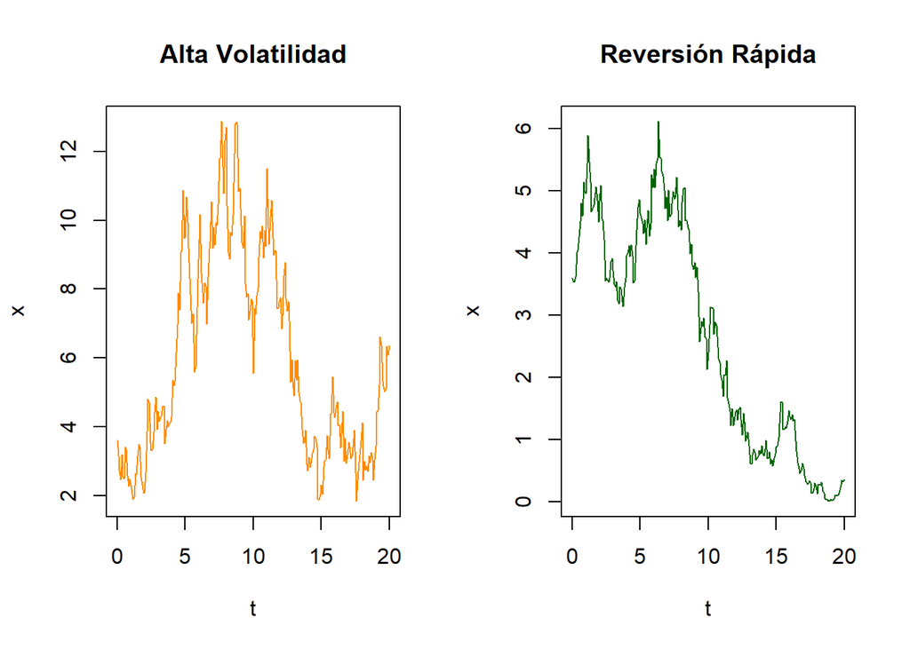

```r
# Prueba de sensibilidad: variando theta3 (volatilidad) y theta2 (velocidad)

# Si aumentamos la volatilidad - theta3 - doblamos volatilidad
params_alta_vol <- as.list(params_estimados)
params_alta_vol$theta3 <- params_alta_vol$theta3*2

sim_vol <- simulate(mejor_modelo, xinit = ultimo_valor,
                    true.parameter = params_alta_vol, sampling = muestreo_sim)


# Si aumentamos la velocidad de reversión - theta2  -- con  retorno a la media mucho más rápido

params_veloz <- as.list(params_estimados)
params_veloz$theta2 <- params_veloz$theta2*2

sim_veloz <- simulate(mejor_modelo, xinit = ultimo_valor,
                      true.parameter = params_veloz, sampling = muestreo_sim)


# Comparación de estabilidad
par(mfrow=c(1,2))
plot(sim_vol, main="Alta Volatilidad", col="darkorange")
plot(sim_veloz, main="Reversión Rápida", col="darkgreen")
```

```r
# Función para obtener un resumen rápido de las simulaciones
resumen_sim <- function(sim_obj, nombre) {
  media <- mean(as.numeric(sim_obj@data@zoo.data[[1]]))
  desv <- sd(as.numeric(sim_obj@data@zoo.data[[1]]))
  cat("\n---", nombre, "---")
  cat("\nMedia de la simulación:", media)
  cat("\nDesviación Típica:", desv, "\n")
}

resumen_sim(simulacion_optima, "Modelo Base (Estimado)")
```

```
##
## --- Modelo Base (Estimado) ---
## Media de la simulación: 3.728475
## Desviación Típica: 0.8839855
```

```r
resumen_sim(sim_vol, "Escenario: Alta Volatilidad")
```

```
##
## --- Escenario: Alta Volatilidad ---
## Media de la simulación: 5.931987
## Desviación Típica: 2.976887
```

```r
resumen_sim(sim_veloz, "Escenario: Reversión Rápida")
```

```
##
## --- Escenario: Reversión Rápida ---
## Media de la simulación: 2.63087
## Desviación Típica: 1.829165
```

## 7. Conclusiones Finales

Tras el análisis exhaustivo de la serie TB3MS, se presentan las siguientes conclusiones:

## 8. Limitaciones

Para finalizar el estudio, es crucial reconocer que un modelo calibrado con casi un siglo de datos (1934-2026) puede no ser el más representativo para entender el presente. La economía ha pasado por etapas muy distintas y, como hemos observado, el comportamiento de los tipos de interés en las últimas dos décadas sigue una lógica propia.

Por ello, hemos realizado una **estimación segmentada desde el año 2000**. Al centrarnos en este intervalo reciente, el modelo CIR se ajusta a un entorno de tipos mucho más bajos y a una “fuerza de atracción” hacia la media mucho más intensa. Esta segmentación nos permite obtener una simulación (línea verde) que es más coherente con el mundo financiero actual, y no con el de hace 80 años.

```r
# Filtramos la serie para quedarnos solo con los últimos 25 años (desde el 2000)
serie_reciente <- window(serie_limpia, start = "2000-01-01")
datos_y_reciente <- setData(serie_reciente, delta = 1/12)

# Creamos el objeto Yuima para la serie reciente con el modelo CIR
yuima_c_reciente <- setYuima(data = datos_y_reciente, model = mod_cir)

# Estimamos los parámetros para la serie reciente
fit_cir_reciente <- qmle(yuima_c_reciente, start = param_init, lower = low_par, upper = up_par)

# Comparación de parámetros: historia completa vs era moderna
coef_total <- coef(fit1)
coef_reciente <- coef(fit_cir_reciente)

cat("\n Comparación de parámetros CIR:\n")
```

```
##
##  Comparación de parámetros CIR:
```

```r
print(rbind(Total_Historia = coef_total, Desde_2000 = coef_reciente))
```

```
##                   theta3     theta1     theta2
## Total_Historia 0.5365377 0.08841239 0.01671654
## Desde_2000     0.5537722 0.09561467 0.08525370
```

```r
# Cálculo del nivel de equilibrio: theta1 / theta2
equilibrio_total <- coef_total["theta1"] / coef_total["theta2"]
equilibrio_reciente <- coef_reciente["theta1"] / coef_reciente["theta2"]

cat("\nNivel de equilibrio total:", equilibrio_total)
```

```
##
## Nivel de equilibrio total: 5.288918
```

```r
cat("\nNivel de equilibrio reciente:", equilibrio_reciente, "\n")
```

```
##
## Nivel de equilibrio reciente: 1.121531
```

```r
cat("\nAIC Total CIR:   ", AIC(fit_cir), "\n")
```

```
##
## AIC Total CIR:    -524.2561
```

```r
cat("AIC Reciente CIR : ", AIC(fit_cir_reciente), "\n")
```

```
## AIC Reciente CIR :  -399.995
```

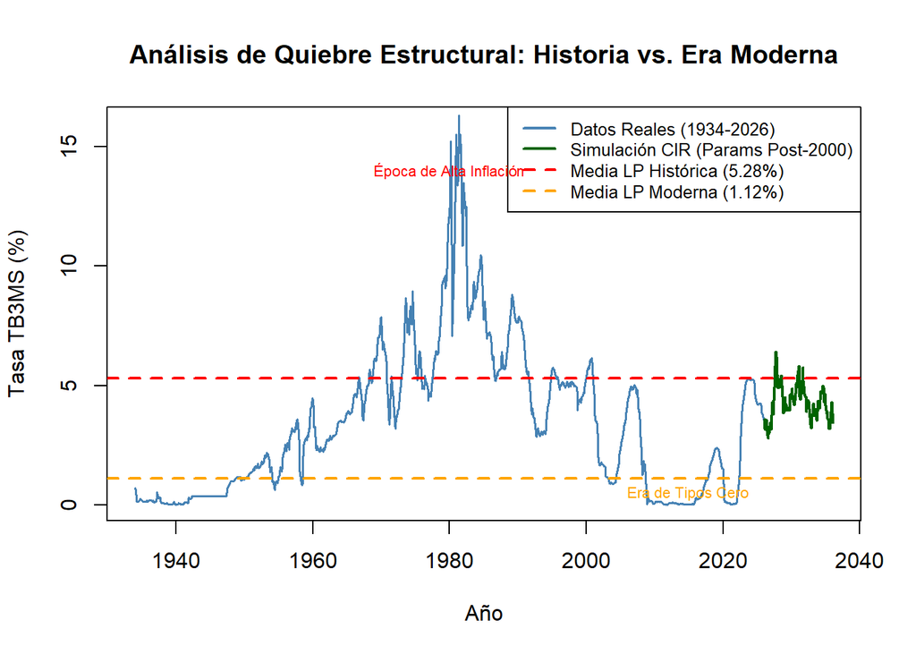

```r
# Definimos los parámetros desde 2000
params_modernos <- as.list(coef_reciente)

# Configuramos la simulación para los próximos 10 años = 120 meses
ultimo_valor_real <- as.numeric(tail(serie_limpia, 1))
muestreo_futuro <- setSampling(Initial = 0, Terminal = 10, n = 120)

set.seed(456) #semilla distinta para otro camino
sim_futura_moderna <- simulate(mod_cir,
                               xinit = ultimo_valor_real,
                               true.parameter = params_modernos,
                               sampling = muestreo_futuro)

# Grafico final

# Convertimos la simulación en un objeto con tiempo real
y_sim <- as.numeric(sim_futura_moderna@data@zoo.data[[1]])

# Creamos un vector de tiempo que empiece justo después del último dato real
ultima_fecha <- index(tail(serie_limpia, 1))
fechas_sim <- seq(from = ultima_fecha, by = "month", length.out = length(y_sim))

# Configuración del grafico
par(mar = c(5, 4, 4, 2) + 0.1)

# Serie histórica completa en azul
plot(index(serie_limpia), as.numeric(serie_limpia),
     type = "l", col = "steelblue", lwd = 1.5,
     main = "Análisis de Quiebre Estructural: Historia vs. Era Moderna",
     xlab = "Año", ylab = "Tasa TB3MS (%)",
     xlim = c(min(index(serie_limpia)), max(fechas_sim)),
     ylim = c(0, 16))

# Simulación del modelo reciente en verde
lines(fechas_sim, y_sim, col = "darkgreen", lwd = 2)

# Líneas de nivel de equilibrio
# Línea de equilibrio Total
abline(h = equilibrio_total, col = "red", lty = 2, lwd = 2)
# Línea de equilibrio Reciente
abline(h = equilibrio_reciente, col = "orange", lty = 2, lwd = 2)

# Leyenda
legend("topright",
       legend = c("Datos Reales (1934-2026)",
                  "Simulación CIR (Params Post-2000)",
                  "Media LP Histórica (5.28%)",
                  "Media LP Moderna (1.12%)"),
       col = c("steelblue", "darkgreen", "red", "orange"),
       lty = c(1, 1, 2, 2),
       lwd = 2,
       cex = 0.8,
       bg = "white")

text(x = as.Date("1980-01-01"), y = 14, "Época de Alta Inflación", cex = 0.7, col = "red")
text(x = as.Date("2015-01-01"), y = 0.5, "Era de Tipos Cero", cex = 0.7, col = "orange")
```